# StormProject

Lynn Kiaer

Sunday, October 26, 2014

# Tornadoes and Thunderstorms Do the Most Damage

## Synopsis

The NOAA Storm Data provides a range of data concerning “hydro-meteorological” events. This analysis used a subset of that data to gain some insight into the human health and economic impact of these events nationwide. After extracting the relevant fields from the data, the data on fatalities and injuries was used to assess health impact, while the property and crop damage data was summed to assess economic impact. After summing the data by event type, tornadoes emerged as the primary threat to human health, accounting for more than one third of all event-related fatalities, and nearly two thirds of the injuries. Tornadoes were also a significant source of economic impact, accounting for more than one quarter of the damage. Grouping together the major thunderstorm-related categories, however, showed that water and wind together produce more damage: more than one third of the total damage could be accounted for by just four thundestorm categories.

## Data Processing

The zipped file *repdata_data_StormData.csv.bz2* was downloaded using the link provided in the assignment, and unzipped to a data directory in the R working directory. The data field was in a nonstandard format. Fields relevant to the questions were extracted for analysis. The EVTYPE field contained many alternate forms of the same event, but the identification of general event types that had the greatest impact ultimately did not depend on this field as much as might have been expected.

```r
rawdata <- read.csv("./data/repdata_data_StormData.csv")
BeginDate <- as.Date(rawdata$BGN_DATE, "%m/%d/%Y")
EvType <- rawdata$EVTYPE
Fatalities <- rawdata$FATALITIES
Injuries <- rawdata$INJURIES
PropDmg <- rawdata$PROPDMG
CropDmg <- rawdata$CROPDMG
temp <- data.frame(EvType, BeginDate, Fatalities, Injuries, PropDmg, CropDmg)
impact <- temp[, 3] > 0 | temp[, 4] > 0 | temp[, 5] > 0 | temp[, 6] > 0
data <- temp[impact,]
healthimpact <- data[, 3] > 0 | data[, 4] > 0
health <- data[healthimpact,]
hresults <- aggregate(health[, 3:6], by = list(health$EvType), sum)
econimpact <- data[, 5] > 0 | data[, 6] > 0
econ <- data[econimpact,]
econ$Total <- econ$PropDmg + econ$CropDmg
eresults <- aggregate(econ[, 3:7], by = list(econ$EvType), sum)
```

## Results

### Events most harmful to population health

The most harmful events with respect to human health are tornadoes. This is based on the following analysis.

```r
colSums(health[, 3:6])
```

```
## Fatalities   Injuries    PropDmg    CropDmg
##      15145     140528    1357941      70168
```

```r
hresults[which(hresults$Fatalities == max(hresults$Fatalities)),]
```

```
##     Group.1 Fatalities Injuries PropDmg CropDmg
## 184 TORNADO       5633    91346  877437   26402
```

Tornadoes represent more than 1/3 of all fatalities (37.2%) and nearly 2/3 (65.0%) of injuries. Even with further manipulation of the event types, no other event approaches this impact.

### Events with the greatest economic consequences

Identifying a single event type with the greatest economic consequences is more challenging. For the purpose of this analysis, economic impact was defined as the sum of the property and crop damage, though one could make an argument that fatalities and injuries have economic impact as well. Tornadoes are a contender, with 27.0% of the total damage, but other events also have significant economic impact: Flash Flood and Flood account for 21.8%, and Thunderstorm Wind, Thunderstorm Winds and Tstm Wind account for 23.3%. Indeed, with the addition of Hail, which generally occurs in conjunction with thunderstorms, the thunderstorm group accounts for more than one third (33.6%) of all property and crop damage. A very strong argument can be made for thunderstorms being the event with the largest economic impact. While further examination of the categories yields many that should be amalgamated into the general “Thunderstorm Wind” category, the vast majority of the tornadoes (and their damage) were entered under a single event type.

```r
sum(econ[, 7])
```

```
## [1] 12262327
```

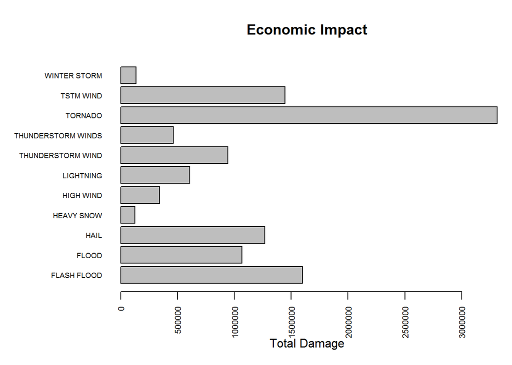

```r
tops <- eresults[eresults$Total > 100000,]
names(tops)[1] <- "Event"
par(mar = c(5,8,4,1))
barplot(tops$Total, horiz = T, names.arg = tops$Event, las = 2, cex.names = 0.6, cex.axis = 0.7, xlab = "Total Damage", main = "Economic Impact")
```